# Summer 2025 Analysis

Samantha Cotton

2026-10-13

## Individual Species Analysis

### Green Frog Analysis

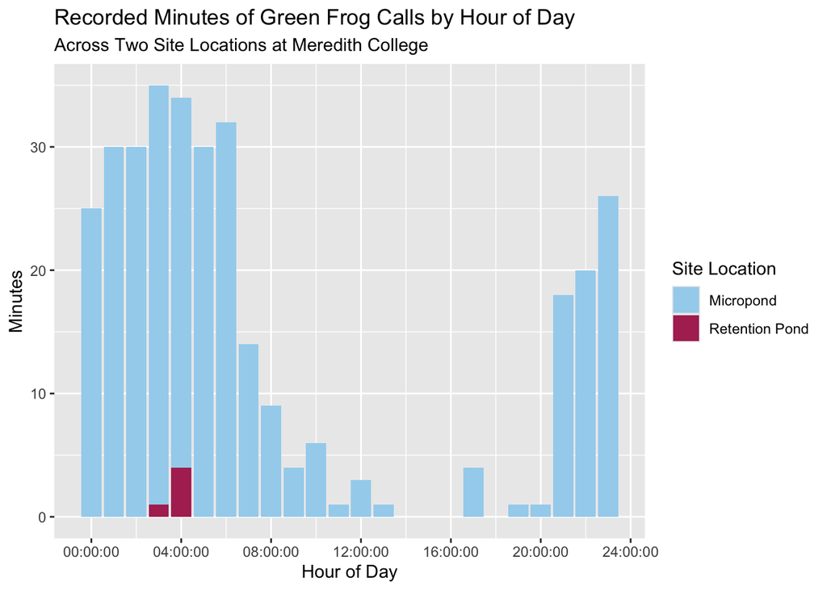

```r
summer_25 %>%
  filter(species_name == "Green Frog") %>%
  ggplot(summer_25, mapping = aes(x = hour_block,
                                  fill = site_name)) +
  geom_bar() +
  labs(x = "Hour of Day",
       y = "Minutes",
       title = "Recorded Minutes of Green Frog Calls by Hour of Day",
       subtitle = "Across Two Site Locations at Meredith College",
       fill = "Site Location") +
  scale_fill_manual(values = c('lightskyblue2', 'maroon'))
```

```r
summer_25 %>%
  filter(species_name == "Green Frog") %>%
  summarize(mins_called = n(),
            median_hour = median(hour_block),
            .groups = "drop_last")
```

```
## # A tibble: 10 × 5
## # Groups:   site_name, species_name [2]
##    site_name      species_name date                mins_called median_hour
##    <chr>          <chr>        <dttm>                    <int> <time>
##  1 Micropond      Green Frog   2025-08-01 00:00:00           4 22:30
##  2 Micropond      Green Frog   2025-08-02 00:00:00          44 05:00
##  3 Micropond      Green Frog   2025-08-03 00:00:00          53 05:00
##  4 Micropond      Green Frog   2025-08-04 00:00:00          70 06:30
##  5 Micropond      Green Frog   2025-08-05 00:00:00          53 05:00
##  6 Micropond      Green Frog   2025-08-06 00:00:00          50 04:30
##  7 Micropond      Green Frog   2025-08-07 00:00:00          13 06:00
##  8 Micropond      Green Frog   2025-08-08 00:00:00          32 03:00
##  9 Retention Pond Green Frog   2025-06-06 00:00:00           2 03:30
## 10 Retention Pond Green Frog   2025-06-07 00:00:00           3 04:00
```

**From this summary table, we can conclude that August 4th had the highest amount of total call minutes of the Green Frog at 70 total minutes, followed by August 3rd and 5th at 53 minutes each, all recorded at the Micropond site.**

### Cope’s Gray Frog Analysis

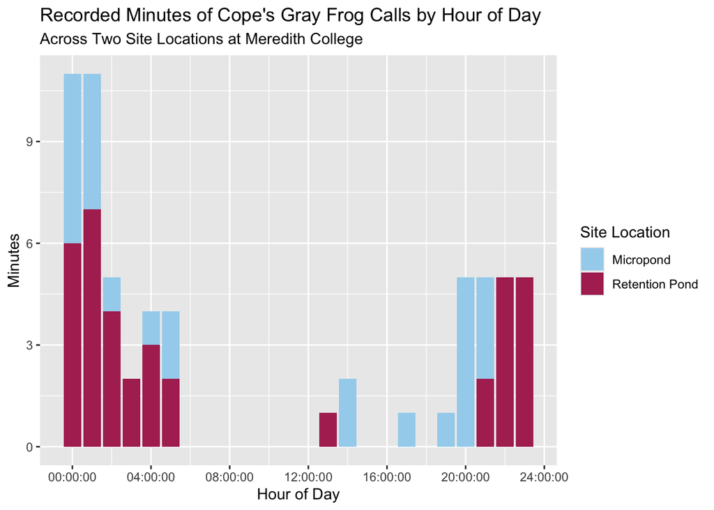

```r
summer_25 %>%
  filter(species_name == "Cope's Gray") %>%
  ggplot(summer_25, mapping = aes(x = hour_block,
                                  fill = site_name)) +
  geom_bar() +
  labs(x = "Hour of Day",
       y = "Minutes",
       title = "Recorded Minutes of Cope's Gray Frog Calls by Hour of Day",
       subtitle = "Across Two Site Locations at Meredith College",
       fill = "Site Location") +
  scale_fill_manual(values = c('lightskyblue2', 'maroon'))
```

```r
summer_25 %>%
  filter(species_name == "Cope's Gray") %>%
  summarize(mins_called = n(),
            median_hour = median(hour_block),
            .groups = "drop_last")
```

```
## # A tibble: 7 × 5
## # Groups:   site_name, species_name [2]
##   site_name      species_name date                mins_called median_hour
##   <chr>          <chr>        <dttm>                    <int> <time>
## 1 Micropond      Cope's Gray  2025-08-02 00:00:00           3 05:00
## 2 Micropond      Cope's Gray  2025-08-06 00:00:00           5 17:00
## 3 Micropond      Cope's Gray  2025-08-07 00:00:00           7 20:00
## 4 Micropond      Cope's Gray  2025-08-08 00:00:00          10 00:30
## 5 Retention Pond Cope's Gray  2025-06-05 00:00:00           1 13:00
## 6 Retention Pond Cope's Gray  2025-06-06 00:00:00          25 05:00
## 7 Retention Pond Cope's Gray  2025-06-07 00:00:00          11 01:00
```

**We can conclude that the typical (median) hour block that Cope’s Gray Frogs have maximum call activity, measured in total minutes of recorded calls, is the 5:00 a.m. hour.**

### Bullfrog Analysis

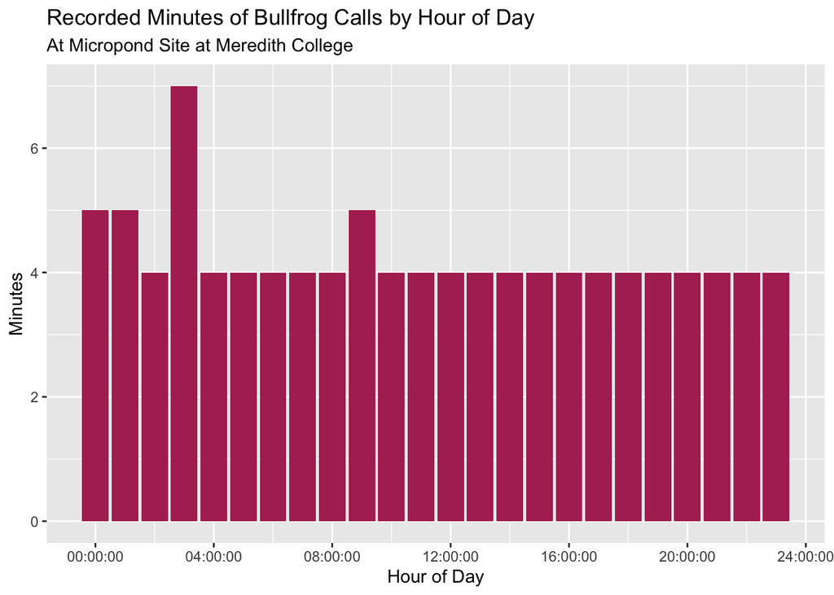

```r
summer_25 %>%
  filter(species_name == "Bullfrog") %>%
  ggplot(summer_25, mapping = aes(x = hour_block,
                                  fill = site_name)) +
  geom_bar() +
  labs(x = "Hour of Day",
       y = "Minutes",
       title = "Recorded Minutes of Bullfrog Calls by Hour of Day",
       subtitle = "At Micropond Site at Meredith College",
       fill = NULL) +
  theme(legend.position = "none") +
  scale_fill_manual(values = c('maroon', 'lightskyblue2'))
```

```r
summer_25 %>%
  filter(species_name == "Bullfrog") %>%
  summarize(mins_called = n(),
            median_hour = median(hour_block, na.rm = TRUE),
            .groups = "drop_last")
```

```
## # A tibble: 4 × 5
## # Groups:   site_name, species_name [1]
##   site_name species_name date                mins_called median_hour
##   <chr>     <chr>        <dttm>                    <int> <time>
## 1 Micropond Bullfrog     2025-08-05 00:00:00          27 10:00
## 2 Micropond Bullfrog     2025-08-06 00:00:00          25 11:00
## 3 Micropond Bullfrog     2025-08-07 00:00:00          25 11:00
## 4 Micropond Bullfrog     2025-08-08 00:00:00          26 11:00
```

**From this summary table, we can conclude that August 5th had the highest amount of recorded call minutes of the Bullfrog at 27 total minutes, followed by August 8th at 26 minutes; all observations of the Bullfrog calls were recorded at the Micropond site.**

### Squirrel Treefrog Analysis

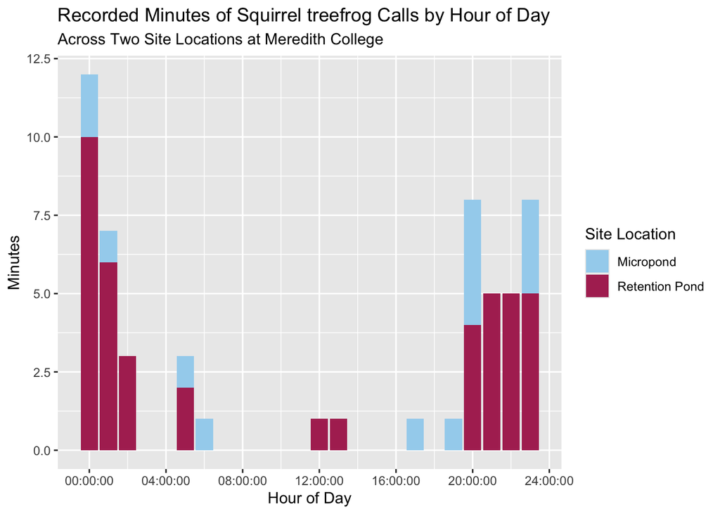

```r
summer_25 %>%
  filter(species_name == "Squirrel treefrog") %>%
  ggplot(summer_25, mapping = aes(x = hour_block,
                                  fill = site_name)) +
  geom_bar() +
  labs(x = "Hour of Day",
       y = "Minutes",
       title = "Recorded Minutes of Squirrel treefrog Calls by Hour of Day",
       subtitle = "Across Two Site Locations at Meredith College",
       fill = "Site Location") +
  scale_fill_manual(values = c('lightskyblue2', 'maroon'))
```

```r
summer_25 %>%
  filter(species_name == "Squirrel treefrog") %>%
  summarize(mins_called = n(),
            median_hour = median(hour_block, na.rm = TRUE),
            .groups = "drop_last")
```

```
## # A tibble: 7 × 5
## # Groups:   site_name, species_name [2]
##   site_name      species_name      date                mins_called median_hour
##   <chr>          <chr>             <dttm>                    <int> <time>
## 1 Micropond      Squirrel treefrog 2025-08-01 00:00:00           4 20:00
## 2 Micropond      Squirrel treefrog 2025-08-02 00:00:00           5 23:00
## 3 Micropond      Squirrel treefrog 2025-08-06 00:00:00           2 18:00
## 4 Micropond      Squirrel treefrog 2025-08-08 00:00:00           3 00:00
## 5 Retention Pond Squirrel treefrog 2025-06-05 00:00:00           2 12:30
## 6 Retention Pond Squirrel treefrog 2025-06-06 00:00:00          28 21:00
## 7 Retention Pond Squirrel treefrog 2025-06-07 00:00:00          12 01:00
```

**From this summary table, we can conclude that June 6th had the highest amount of recorded call minutes of the Squirrel treefrog at 28 total minutes, followed by June 7th at 12 minutes; both were recorded at the Retention Pond site.**

**We can conclude that the typical (median) hour block that Squirrel treefrogs have maximum call activity, measured in total minutes of recorded calls, is the 9:00 p.m. hour.**

### Green Treefrog Analysis

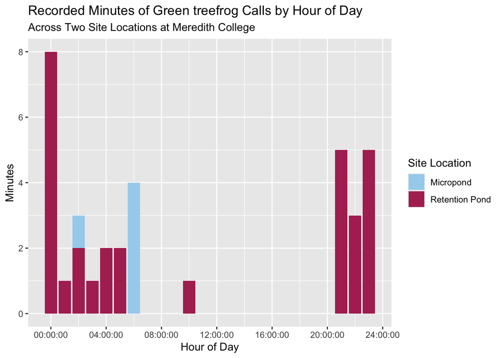

```r
summer_25 %>%
  filter(species_name == "Green treefrog") %>%
  ggplot(summer_25, mapping = aes(x = hour_block,
                                  fill = site_name)) +
  geom_bar() +
  labs(x = "Hour of Day",
       y = "Minutes",
       title = "Recorded Minutes of Green treefrog Calls by Hour of Day",
       subtitle = "Across Two Site Locations at Meredith College",
       fill = "Site Location") +
  scale_fill_manual(values = c('lightskyblue2', 'maroon'))
```

```r
summer_25 %>%
  filter(species_name == "Green treefrog") %>%
  summarize(mins_called = n(),
            median_hour = median(hour_block),
            .groups = "drop_last")
```

```
## # A tibble: 6 × 5
## # Groups:   site_name, species_name [2]
##   site_name      species_name   date                mins_called median_hour
##   <chr>          <chr>          <dttm>                    <int> <time>
## 1 Micropond      Green treefrog 2025-08-02 00:00:00           2 06:00
## 2 Micropond      Green treefrog 2025-08-04 00:00:00           1 06:00
## 3 Micropond      Green treefrog 2025-08-05 00:00:00           1 06:00
## 4 Micropond      Green treefrog 2025-08-08 00:00:00           1 02:00
## 5 Retention Pond Green treefrog 2025-06-06 00:00:00          25 21:00
## 6 Retention Pond Green treefrog 2025-06-07 00:00:00           5 00:00
```

**From this summary table, we can conclude that June 6th had the highest amount of recorded call minutes of the Green Treefrog at 25 total minutes, followed by June 7th at 5 minutes; both were recorded at the Retention Pond site.**

**We can conclude that the typical (median) hour block that Green Treefrogs have maximum call activity, measured in total minutes of recorded calls, is the 9:00 p.m. hour.**

## Comparing Across Site Locations

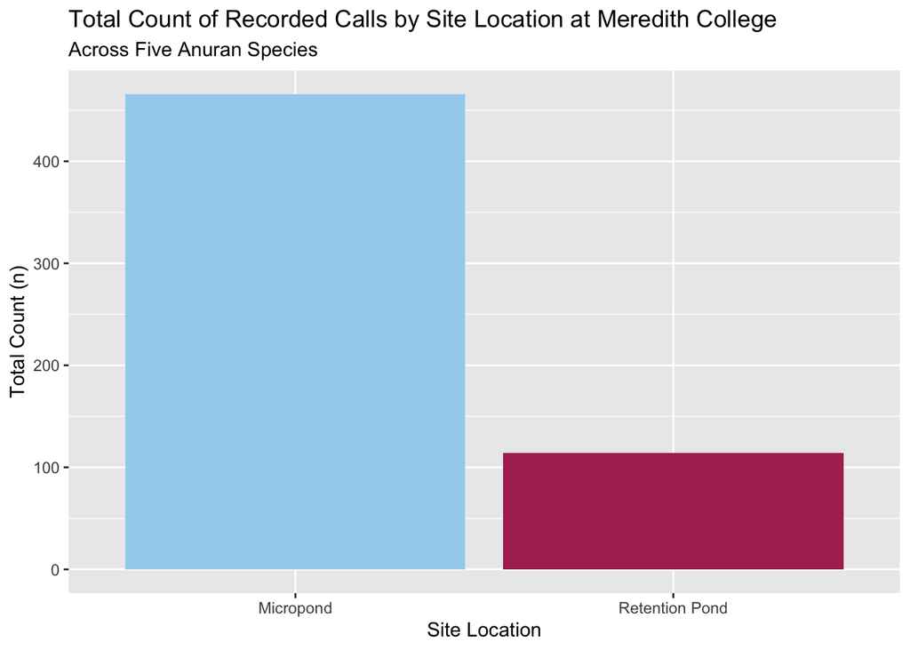

```r
summer_25 %>%
  group_by(site_name) %>%
  summarize(total_recordings = n()) %>%
  ggplot(mapping = aes(x = site_name,
                       y = total_recordings,
                       fill = site_name)) +
  geom_col() +
  labs(x = "Site Location",
       y = "Total Count (n)",
       title = "Total Count of Recorded Calls by Site Location at Meredith College",
       subtitle = "Across Five Anuran Species",
       fill = NULL) +
  theme(legend.position = "none") +
  scale_fill_manual(values = c('lightskyblue2', 'maroon'))
```

**From this visualization, we can conclude the Micropond site had more observations of recorded calls by identified anuran species compared to the Retention Pond site.**

## Comparing Across Species

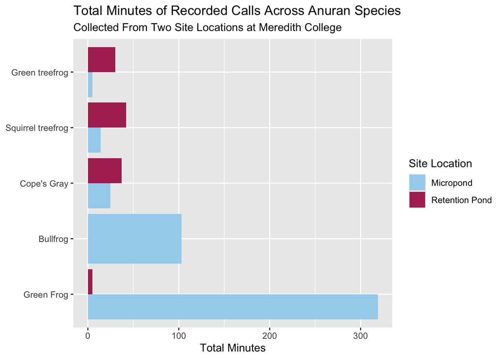

```r
summer_25 %>%
  group_by(site_name, species_name, date) %>%
  summarize(total_mins = n(),
            .groups = "drop_last") %>%
  summarize(total_mins_called = sum(total_mins),
            .groups = "drop_last") %>%
  ungroup() %>%
  mutate(species_name = fct_reorder(species_name, desc(total_mins_called))) %>%
  ggplot(summer_25, mapping = aes(x = total_mins_called,
                                  y = species_name,
                                  fill = site_name)) +
  geom_col(position = "Dodge") +
  labs(x = "Total Minutes",
       y = NULL,
       fill = "Site Location",
       title = "Total Minutes of Recorded Calls Across Anuran Species",
       subtitle = "Collected From Two Site Locations at Meredith College") +
  scale_fill_manual(values = c('lightskyblue2', 'maroon'))
```

**From this visualization, we can conclude that across the five recorded species, the Green Frog had the highest count of recorded calling minutes, with most observations having been recorded at the Micropond site. The total calling minutes of the Bullfrog was the second highest, but observations occurred solely at the Micropond site. The Green Treefrog appears to have the smallest amount of recorded calling minutes across the five species; along with the Squirrel treefrog and the Cope’s Gray frog, it had more recorded calling minutes at the Retention Pond site than the Micropond site.**

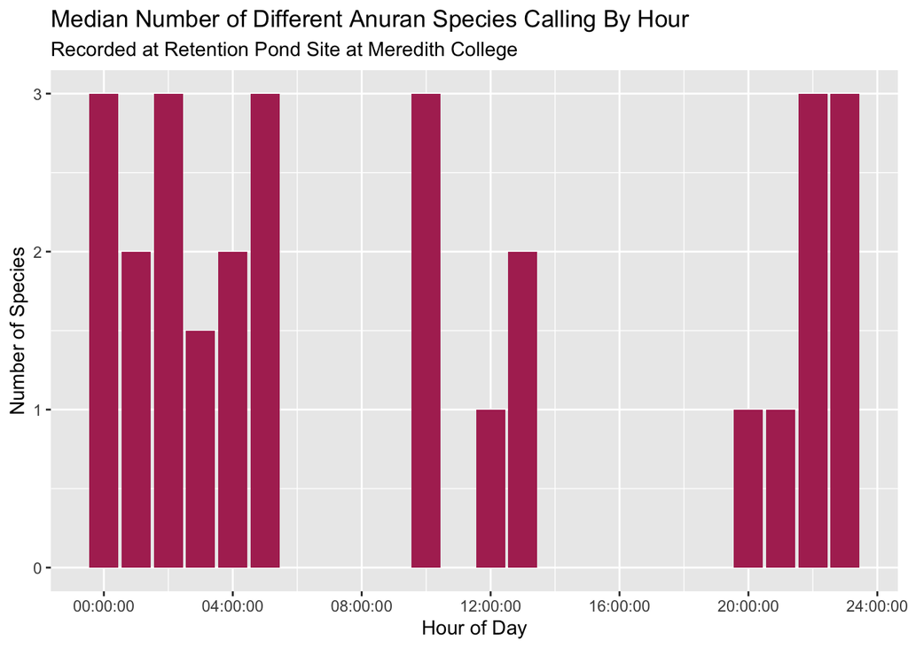

```r
summer_25 %>%
  filter(site_name == "Retention Pond") %>%
  group_by(hour_block) %>%
  summarize(median_calls = median(total_species_calling)) %>%
  ggplot(summer_25, mapping = aes(x = hour_block,
                                  y = median_calls)) +
  geom_col(position = "Dodge", fill = 'maroon') +
  labs(x = "Hour of Day",
       y = "Number of Species",
       title = "Median Number of Different Anuran Species Calling By Hour",
       subtitle = "Recorded at Retention Pond Site at Meredith College")
```

**Gaps in certain hour blocks of this visualization is due to an absence of data for that hour block.**

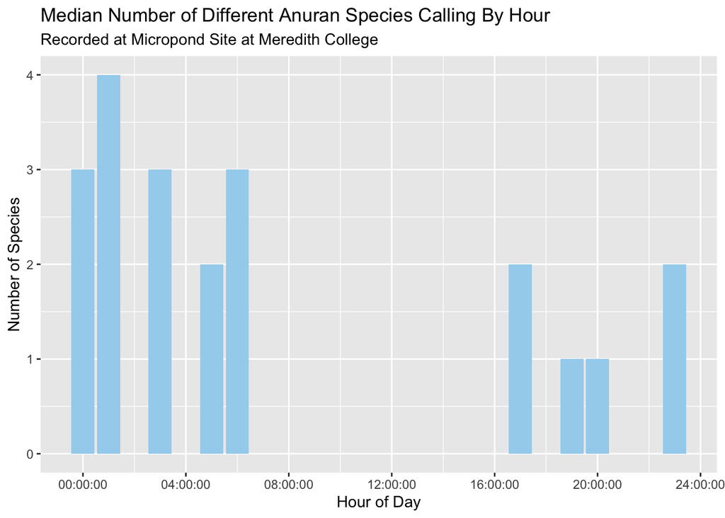

```r
summer_25 %>%
  filter(site_name == "Micropond") %>%
  group_by(hour_block) %>%
  summarize(median_calls = median(total_species_calling, na.rm = TRUE)) %>%
  ggplot(summer_25, mapping = aes(x = hour_block,
                                  y = median_calls)) +
  geom_col(position = "Dodge", fill = 'lightskyblue2') +
  labs(x = "Hour of Day",
       y = "Number of Species",
       title = "Median Number of Different Anuran Species Calling By Hour",
       subtitle = "Recorded at Micropond Site at Meredith College")
```

**Gaps in certain hour blocks of this visualization is due to an absence of data for that hour block.**